# Determining accuracy of gully features in a DEM

Team Gully Bully: David Scholte-Albers

Friday, January 30, 2015

# Introduction

Thesis about classification of Gullies in Navarre, Spain

- DEM made from UAV (12cm resolution)
- Field measurements

**Research Question:** *Are gully features visible in the DEM and to what extent?*

**Objective:** *Find out what the difference in gully profile is when comparing ground truth measurements with DEM crosssections.*

# Gullies in the field look like this

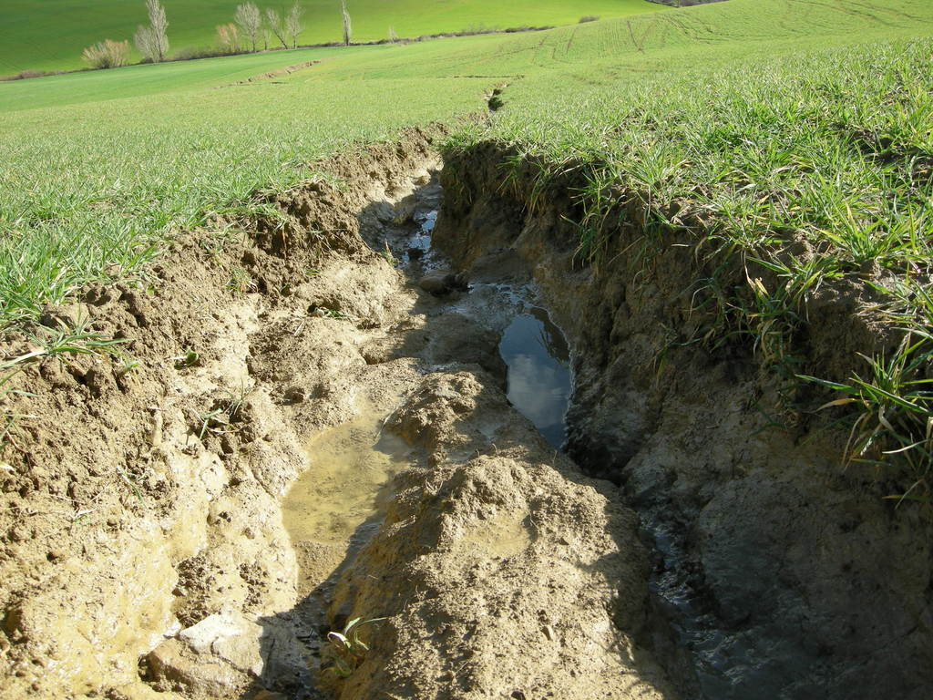

# Steps to take

1. Extract DEM values for the same locations as ground truth cross sections with Python
2. Save results in .csv files that can be loaded into R
3. Conduct analysis in R

[figure not shown]

# Python

```r
# Load required toolbox for creating points from a line
arcpy.ImportToolbox("D:/GS_Final/Scripting/Python/CreatePointsFromLinesTool.pyt")

# Set GPS points in the expression below or choose them when running the model in ArcGIS.
# Replace one of the following GPS-point combinations for the 001 and 003 in the expression.
# (001, 003); (013, 016); (026, 028); (039, 041); (048, 050);
# (073, 075); (078, 079); (0115, 0117); (0146, 0147); (0148, 0149)

Expression = "\"id\" = 'TEJGUL001' OR \"id\" = 'TEJGUL003'"
arcpy.Select_analysis(GPS_Points_Tejeria_shp, Selected_Points, Expression)

# Processes:  Points To Line > Create Points Along Lines >
#             Extract Values to Points > Add Field (Distance)
#             Calculate Field (Distance) >

# Export Feature Attribute to ASCII
# Change the numbers in Tej_1_3 into the GPS points specified in the select tool.
Tej_1_3_csv = "D:\\GS_Final\\data\\Results.gdb\\Tej_1_3.csv"
arcpy.ExportXYv_stats(Values_Extracted_To_Points__3_, Value_Field, Delimiter,
                      Tej_1_3_csv, Add_Field_Names_to_Output)
```

# R - Initialisation

```r
rm(list = ls())
ls()

# Set Username
username <- "Gully Bully"

# Check Working Directory
setwd("D:/GS_Final")
getwd()

# import libraries
library(ggplot2)
library(gridExtra)

# import functions
source("Final_Project/R/FinalProjectDavid/Load_Field_and_DEM_CSV_Data.R")
source("Final_Project/R/FinalProjectDavid/Make_Gully_Plots.R")
source("Final_Project/R/FinalProjectDavid/Combine_Plots.R")
source("Final_Project/R/FinalProjectDavid/Conclusion.R")
```

# R - Data Processing

```r
# Function for loading the gully .csv data. Changing the numbers in the GPS_points
# vector, will load data for a different gully.
GPS_points <- c(26,28) # Specify numbers based on above list
DEM_values <- load_dem_data(GPS_points[1], GPS_points[2])
Field_values <- load_field_data(GPS_points[1], GPS_points[2])

load_dem_data <- function (GPSpoint1, GPSpoint2) {
  file_loc <- paste("DEMs/Results.gdb/Tej_", GPSpoint1, "_", GPSpoint2,
                    ".csv", sep="")
  Gully_DEM<- read.csv(file_loc)
}

load_field_data <- function (GPSpoint1, GPSpoint2) {
  file_loc <- paste("DEMs/Results.gdb/Tej_", GPSpoint1, "_", GPSpoint2,
                    "_field_meas.csv", sep="")
  Gully_DEM<- read.csv(file_loc, sep=";")
}
# Add Depth Field to Gully_DEM
DEM_values$Depth <- DEM_values$RASTERVALU[1] - DEM_values$RASTERVALU
```

# R - Data Visualisation

```r
# Function that will extract the columns of interest from the data frames,
# for creating crosssections of the same gully (DEM & Field measurements).
make_dem_plot <- function(Gully_DEM) {
  Depth_DEM <- Gully_DEM$Depth
  Distance_DEM <- Gully_DEM$DISTANCE
  ggplot(data=Gully_DEM, aes(x=DISTANCE, y=Depth, group=1)) +
    geom_line(colour="red", size=2) +
    geom_point(colour= "black", size=4) +
    xlim(0, max(Distance_DEM)) +
    ylim(max(Depth_DEM), -0.1) +
    xlab("Distance (m)") + ylab("Depth (m)") + ggtitle("Gully Cross Section DEM")
}
```

# Plots of the DEM profile (left) and Field profile (right)

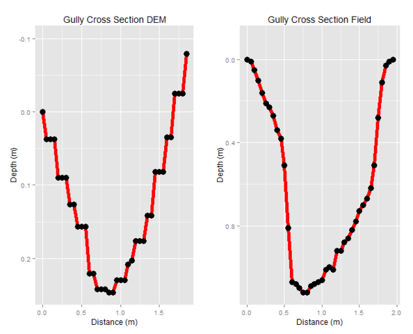

```r
plot_DEM <- make_dem_plot(DEM_values)
plot_field <- make_field_plot(Field_values)
grid.arrange(plot_DEM, plot_field, ncol=2)
```

# Plotting the profiles and their difference in the same plot

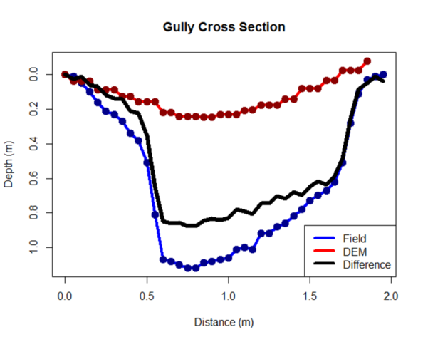

```r
# Plot DEM and Field profile in same plot and add a profile of the difference
make_plot(DEM_values, Field_values)
lines(Field_values$Length, difference_per_5_cm, lwd=6, col="Black")
legend("bottomright", c("Field","DEM", "Difference"), lty=c(1,1,1), lwd=c(4, 4, 4),col=c("blue","red", "Black")) #add legend
```

# Conclusion

```r
print(conclusion())
```

[1] “Welcome Gully Bully! Thank you for using this lovely tool to determine the difference in depth between a real gully and the same gully in a DEM. The GPS points you chose (26 and 28) createad a nice gully crosssection. The accuracy of the DEM however is a bit disappointing, because there is a mean difference of 0.49m and a mean standard deviation of 0.33m. The largest difference between DEM and field measurement is 0.88m. Thank you for using this tool, we hope to see you again.”

# What have I learned from this course

- Structure your code, and think about the steps to take before starting right ahead.
- Organize your data. Again, in the last week my data was all over the place. It takes longer to get the data back in order, than to keep the data structured from the start.
- I was slightly afraid of scripts and programming. Being thrown in at the deep end several times during this course, and finally figuring out (with lots of trial and error) what to do actually feels satisfying and gives confidence (and a headache).